# NFL Team Building Strategy - Optimising Receiver Corps

## Introduction

This offseason in the National Football League (NFL), two teams, the Chiefs and the Packers, who have two of the best receivers in the league, Tyreek Hill and Devante Adams, have traded those players away. In turn, they got many draft picks, and it seems these teams' strategies are to have more good receivers rather than having 1-2 star receivers, with the rest of the receiving corps being significantly below average. This brings up an interesting team-building strategy question in a salary-capped league: is it better to have a top-heavy receiving corps with superstars that change the math of the game, or is it better to have a unit of more reliable receivers without one gamechanger?

First, I'll explain a little bit about the salary cap in the NFL. According to [Bleacher Report](https://bleacherreport.com/articles/1665623-how-does-the-salary-cap-work-in-the-nfl), "A salary cap is essentially an agreement between the league and players that places a limit on the amount of money a team can spend on salaries for players. The NFL uses a hard cap, meaning that no team is allowed to exceed the cap limit for any reason." The cap balances the league, ensuring that teams have to employ strategy in team building rather than being able to buy the best team possible, which can create a boring league with the wealthiest teams dominating the game.

The salary cap forces teams to prioritize where they put their money. Building a team is like recruiting. You want the best players to come to you, and one of the ways to do that is by paying them the most money. But you also want to make sure that you are not putting too much money in one area or player because if you do so, the salary cap will prevent you from investing as much in the rest of the team. Two big things that need to be taken into account when thinking about money allocation in team building are positional value and the value of each individual player. Pro Football Focus (PFF), a football analytics company, has a metric called Wins Above Replacement (WAR), which estimates roughly how many wins an individual player has contributed to his team. Meaning, that you should subtract a player's WAR from the team's total wins to say how many wins the team would have if you were to replace the player with an average one. WAR is a way of calculating the value of a specific player but also tells us a lot about positional value. This chart from PFF shows the average WAR of the top 10 players from each position from 2019:

[figure not shown]

Data shows that in the modern NFL, which is a passing league, after Quarterback, wide receivers are the most valuable position on the team. While there is a lot of data on individual player value and positional value, there isn't a lot of research on what combinations of players make for the best position group. As in, what combination of wide receivers gives you the best receiving corps? On the one hand, receivers can completely change the math of the game, especially when it comes to star receivers. When one receiver needs two defenders on him at all times or is so fast that the opposing team needs to adjust their entire defensive scheme for him, he's valuable and impacting the game even when he doesn't touch the ball.

On the other hand, it's just one player, which great defensive coaches can figure out how to shut down. And if that happens, while the remainder of your receiving corps is not very reliable due to the money spent on the star, is it better to have 2 or 3 above average players than being top-heavy? Were the Cheifs and Packers right in opting to pay one individual player less and spreading their money across receivers more equally, or did the teams that acquired Tyreek Hill and Devante Adams have the right idea?

In this tutorial, we will inspect PFF data and develop a model that can take in the performance grades of 4 receivers and predict the total receiving corp performance based on the performance. This can allow general managers (GMs) to look at the receivers they have and run the model with different free-agent receivers and try to predict the total performance of those hypothetical receiving corps.

## Part 1: Gathering the data

First, we need to gather and decide what data to use. While many people look at standard statistics in football, like touchdowns, percentage of targets caught, and yards per reception, many of these traditional statistics are flawed and don't provide context. Firstly, it only evaluates a player's performance when targeted, so it doesn't account for how they impact the rest of the game. Additionally, football is the ultimate team sport, and a lot of those traditional statistics are dependent on the performance of everyone around the receiver, not just the receiver's performance. So, for example, if a receiver completely runs the wrong route, the quarterback finds him despite his mistake, and he gets a touchdown; the receiver gets credit even though he did something wrong. PFF evaluates every player on every play, which helps account for their performance when players are not touching the ball. In addition, this grading method isolates player performance, so players don't get penalized for other players' mistakes or credit for other players' great plays. These grades are out of 100, and usually, anything above 90 is considered elite, but the average grade varies with position. PFF also has grades for team units, like grades for a team's offense, defense, receiving corp, secondary, etc. So we will use individual player grades and the team receiving corps grades to train our model.

One consideration we have to make is how many years of data do we want? On the one hand, more data helps us train our model better, but on the other hand, the game of football has rapidly changed over the past 5-10 years, so going too far back can train the model with data that is no longer relevant to today's NFL. To decide how far back to go, I wanted to find a point from one year to another that made it clear the NFL started valuing receivers significantly more. I looked at overthecap.com and how much the teams that spend the most money on receivers spent. There was a big jump from 2016 to 2017:

#### 2015 | 2016 | 2017

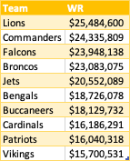

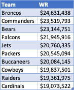

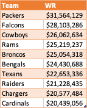

As you can see, the shift from 2016 to 2017 is far more drastic than from 2015 to 2016 and generally consistent with the general shift around football to even more of an emphasis on passing. As a fan, it's clear to see how the game has changed over the past few years and the explosion of passing offenses, especially with so many young talented quarterbacks with really strong arms. This influx started around the 2017 season, and 2017 feels like a good place to define a starting point for this newer era of football.

### Getting Reciever Grades

First, we will collect the receiver grades from PFF. I decided to include tight ends (TE) in the data because a few tight ends in the league fill the role of receiver. For example, the Cheifs can justify trading away Tyreek Hill because they have Travis Kelce, a TE who is one of the league's best receivers. Calculating the Cheif's receiving corp without him would not make sense because he is now their best receiver. On the other hand, TEs like Kelce are an anomaly, and not all TEs get the number of targets as him. To prevent TEs or WRs who are buried on the depth chart from skewing the data, only the grades of the receivers with the top 4 targets will go into the model, but I will explain more about that later.

```python
import requests
from bs4 import BeautifulSoup
import pandas as pd
import numpy as np
import matplotlib.pyplot as plt
import seaborn as sns

import statsmodels.api as sm
from statsmodels.formula.api import ols
import statsmodels.stats.api as sms
import statsmodels.tsa.api as smt
from statsmodels.stats.stattools import durbin_watson

import sklearn.metrics as met
import sklearn.model_selection as ms
from sklearn.linear_model import LinearRegression
```

```python
recievers2021 = pd.read_csv("receiving_summary_2021.csv")
recievers2021['year'] = 2021 # add a column to represent year

recievers2020 = pd.read_csv("receiving_summary_2020.csv")
recievers2020['year'] = 2020

recievers2019 = pd.read_csv("receiving_summary_2019.csv")
recievers2019['year'] = 2019

recievers2018 = pd.read_csv("receiving_summary_2018.csv")
recievers2018['year'] = 2018

recievers2017 = pd.read_csv("receiving_summary_2017.csv")
recievers2017['year'] = 2017

# combine each year's data
receiver_summary = pd.concat([recievers2021, recievers2020, recievers2019, recievers2018, recievers2017])
receiver_summary = receiver_summary[(receiver_summary.position != 'HB')] # removing running backs
receiver_summary.head()
```

|  | player | player_id | position | team_name | player_game_count | avg_depth_of_target | avoided_tackles | caught_percent | contested_catch_rate | contested_receptions | ... | targets | touchdowns | wide_rate | wide_snaps | yards | yards_after_catch | yards_after_catch_per_reception | yards_per_reception | yprr | year |
| --- | --- | --- | --- | --- | --- | --- | --- | --- | --- | --- | --- | --- | --- | --- | --- | --- | --- | --- | --- | --- | --- |
| 0 | Cooper Kupp | 11824 | WR | LA | 21 | 8.8 | 30 | 77.4 | 53.8 | 14 | ... | 230 | 22 | 32.1 | 265 | 2425 | 1070 | 6.0 | 13.6 | 3.12 | 2021 |
| 1 | Tyreek Hill | 10799 | WR | KC | 20 | 10.6 | 15 | 73.6 | 28.6 | 6 | ... | 182 | 12 | 45.3 | 344 | 1524 | 576 | 4.3 | 11.4 | 2.14 | 2021 |
| 2 | Davante Adams | 8688 | WR | GB | 17 | 9.7 | 13 | 74.6 | 50.0 | 14 | ... | 177 | 11 | 66.8 | 413 | 1643 | 650 | 4.9 | 12.4 | 2.81 | 2021 |
| 3 | Diontae Johnson | 33441 | WR | PIT | 17 | 9.0 | 16 | 63.6 | 39.1 | 9 | ... | 176 | 9 | 92.9 | 651 | 1195 | 542 | 4.8 | 10.7 | 1.83 | 2021 |
| 4 | Stefon Diggs | 9579 | WR | BUF | 19 | 11.8 | 17 | 64.9 | 46.9 | 15 | ... | 168 | 10 | 78.6 | 588 | 1292 | 338 | 3.1 | 11.9 | 1.84 | 2021 |

5 rows × 46 columns

Additionally, as you can see above, a line of code removes players with the position HB, which is a halfback (a type of runningback). Running backs get receptions sometimes, but they are not considered part of a receiving corp in the same way a WR or TE is a receiver, so they need to be left out.

### Getting Team Receiver Unit Grades

I followed the same process as I did above with the receiver data for the team summaries, which contains the team receiving grades.

```python
teams2021 = pd.read_csv("team_summary_2021.csv")
teams2021['year'] = 2021 # add a column to represent year

teams2020 = pd.read_csv("team_summary_2020.csv")
teams2020['year'] = 2020

teams2019 = pd.read_csv("team_summary_2019.csv")
teams2019['year'] = 2019

teams2018 = pd.read_csv("team_summary_2018.csv")
teams2018['year'] = 2018

teams2017 = pd.read_csv("team_summary_2017.csv")
teams2017['year'] = 2017

team_summaries = pd.concat([teams2021, teams2020, teams2019, teams2018, teams2017]) # combine each year's data
team_summaries.head()
```

|  | TEAM | PF | PA | OVER | OFF | PASS | PBLK | RECV | RUN | RBLK | DEF | RDEF | year |
| --- | --- | --- | --- | --- | --- | --- | --- | --- | --- | --- | --- | --- | --- |
| 0 | Arizona Cardinals | 460 | 400 | 76.6 | 73.8 | 82.8 | 66.3 | 78.7 | 68.0 | 52.4 | 62.2 | 49.4 | 2021 |
| 1 | Atlanta Falcons | 313 | 459 | 69.6 | 74.7 | 72.1 | 52.6 | 76.5 | 62.2 | 80.4 | 48.8 | 43.1 | 2021 |
| 2 | Baltimore Ravens | 387 | 392 | 80.4 | 75.5 | 66.0 | 69.7 | 72.2 | 82.5 | 72.3 | 62.5 | 61.1 | 2021 |
| 3 | Buffalo Bills | 566 | 348 | 89.0 | 81.1 | 81.1 | 69.0 | 79.4 | 92.7 | 58.4 | 71.8 | 55.3 | 2021 |
| 4 | Carolina Panthers | 304 | 404 | 63.2 | 60.4 | 50.1 | 53.9 | 63.1 | 72.6 | 58.7 | 62.6 | 52.2 | 2021 |

## Part 2: Transforming the Data

We are not sure what model will fit this data, but we will start with a linear regression and run some tests to see if the data is linear. The regression will have the grades of every team's top 4 receivers as the independent variable, and the teams total receiving grade will be the dependent variable. So we have to transform the top 4 receivers from each team on a given year into one row where there are columns for each receiver.

The first step is to add a row of team abbreviations to the team summaries table so we can match up teams and receivers from the receivers table. We will use the nfl_team.csv file for this.

```python
nfl_team_info = pd.read_csv("nfl_teams.csv") # NFL team data - name, team abbriviation, etc
nfl_team_info.head()
```

|  | ID | Name | Abbreviation | Conference | Division |
| --- | --- | --- | --- | --- | --- |
| 0 | 1.0 | Arizona Cardinals | ARZ | NFC | West |
| 1 | 2.0 | Atlanta Falcons | ATL | NFC | South |
| 2 | 3.0 | Baltimore Ravens | BLT | AFC | North |
| 3 | 4.0 | Buffalo Bills | BUF | AFC | East |
| 4 | 5.0 | Carolina Panthers | CAR | NFC | South |

```python
# Rename the column to Name so we can merge with nfl_team_info to get Abbriviation
team_summaries = team_summaries.rename(columns={'TEAM': 'Name'})

rec_data = pd.merge(nfl_team_info, team_summaries, how ='inner', on=['Name'])

# rename columns so it'll match better with the receiver_summary naming conventions
rec_data = rec_data.rename(columns={'RECV': 'team_grades_pass_route', 'Abbreviation': 'team_name', 'Name': 'full_name'})

# drop data that is irrelevant
rec_data = rec_data.drop(columns=['ID', 'Conference', 'Division', 'PF', 'PA', 'OVER', 'OFF',
                                  'PASS', 'PBLK', 'DEF', 'RDEF'])

rec_data.head()
```

|  | full_name | team_name | team_grades_pass_route | RUN | RBLK | year |
| --- | --- | --- | --- | --- | --- | --- |
| 0 | Arizona Cardinals | ARZ | 78.7 | 68.0 | 52.4 | 2021 |
| 1 | Arizona Cardinals | ARZ | 75.4 | 75.9 | 60.7 | 2020 |
| 2 | Arizona Cardinals | ARZ | 67.7 | 81.1 | 56.0 | 2019 |
| 3 | Arizona Cardinals | ARZ | 61.7 | 62.2 | 59.8 | 2018 |
| 4 | Arizona Cardinals | ARZ | 67.6 | 58.6 | 62.4 | 2017 |

```python
# drop irrelevant receiver data
receiver_grades = receiver_summary[['player', 'position', 'team_name', 'year', 'grades_pass_route', 'targets']]
receiver_grades.head()
```

|  | player | position | team_name | year | grades_pass_route | targets |
| --- | --- | --- | --- | --- | --- | --- |
| 0 | Cooper Kupp | WR | LA | 2021 | 93.1 | 230 |
| 1 | Tyreek Hill | WR | KC | 2021 | 85.6 | 182 |
| 2 | Davante Adams | WR | GB | 2021 | 92.8 | 177 |
| 3 | Diontae Johnson | WR | PIT | 2021 | 73.8 | 176 |
| 4 | Stefon Diggs | WR | BUF | 2021 | 81.9 | 168 |

Now that we have our team and receiver data formatted nicely we will merge the two datasets.

```python
merged = pd.merge(rec_data, receiver_grades, how ='outer', on=['year', 'team_name'])
merged.head()
```

|  | full_name | team_name | team_grades_pass_route | RUN | RBLK | year | player | position | grades_pass_route | targets |
| --- | --- | --- | --- | --- | --- | --- | --- | --- | --- | --- |
| 0 | Arizona Cardinals | ARZ | 78.7 | 68.0 | 52.4 | 2021 | Christian Kirk | WR | 72.7 | 112.0 |
| 1 | Arizona Cardinals | ARZ | 78.7 | 68.0 | 52.4 | 2021 | Zach Ertz | TE | 69.4 | 112.0 |
| 2 | Arizona Cardinals | ARZ | 78.7 | 68.0 | 52.4 | 2021 | A.J. Green | WR | 69.7 | 93.0 |
| 3 | Arizona Cardinals | ARZ | 78.7 | 68.0 | 52.4 | 2021 | Rondale Moore | WR | 70.1 | 70.0 |
| 4 | Arizona Cardinals | ARZ | 78.7 | 68.0 | 52.4 | 2021 | DeAndre Hopkins | WR | 81.1 | 59.0 |

But this merge isn't exactly what we wanted. We need each team and year combination to be one row that contains the team passing grade and the top 4 players on each team's individual grades. We need to do a bit more manipulation. We will go through each team and then add a row for each year associated with that team to a new dataframe we are building.

Additionally, we define the top 4 not by grade but by the number of targets they get. Each player will be ordered in terms of how much they are relied on. So the receiver that gets the most targets is considered the number 1 receiver and not the receiver with the highest grade. If we sorted by the receiver with the highest grade, there could be receivers who have been on the field for two games and got five targets and have an excellent grade. But that doesn't tell us much about the receiving corp and the player's effect on the team.

```python
team_groupings = merged.groupby('team_name') # group by team name
team_names = nfl_team_info['Abbreviation'].tolist() # a list of all team names

df = pd.DataFrame()
i = 0
for name in team_names:
    # the data associated with the team we are currently evaluating and then group that data by years
    team = team_groupings.get_group(name).groupby('year')
     # since some teams names have changed not all team names so only get the years associated with that team name
    years = list(team.groups.keys())
    for year in years:
        # get a dataframe with the top 4 receivers with the most targets in this team, year combination
        top4 = team.get_group(year).nlargest(n=4, columns=['targets'])

        # add the team data to a new df
        to_add = pd.DataFrame({'full_name': top4['full_name'].iloc[0],
                               'team_name': name,
                               'team_grades_pass_route': top4['team_grades_pass_route'].iloc[0],
                               'year': year
                              }, index=[i])
        j = 1
        for index, row in top4.iterrows(): # go through each row of the top 4 players and add their grade as a column
            to_add['player{}_rec_grade'.format(j)] = row.grades_pass_route
            j += 1

        if df.empty:
            df = to_add
        else:
            df = pd.concat([df, to_add]) # in each year get the rows with the top 4 passing routes
        i += 1
df.head()
```

|  | full_name | team_name | team_grades_pass_route | year | player1_rec_grade | player2_rec_grade | player3_rec_grade | player4_rec_grade |
| --- | --- | --- | --- | --- | --- | --- | --- | --- |
| 0 | Arizona Cardinals | ARZ | 67.6 | 2017 | 78.8 | 57.9 | 58.2 | 58.8 |
| 1 | Arizona Cardinals | ARZ | 61.7 | 2018 | 72.3 | 54.3 | 70.1 | 52.7 |
| 2 | Arizona Cardinals | ARZ | 67.7 | 2019 | 71.6 | 62.0 | 64.0 | 53.4 |
| 3 | Arizona Cardinals | ARZ | 75.4 | 2020 | 88.0 | 62.5 | 61.1 | 64.4 |
| 4 | Arizona Cardinals | ARZ | 78.7 | 2021 | 72.7 | 69.4 | 69.7 | 70.1 |

```python
print(df[pd.notnull(df["player1_rec_grade"])]["player1_rec_grade"].count())
print(df[pd.notnull(df["player2_rec_grade"])]["player2_rec_grade"].count())
print(df[pd.notnull(df["player3_rec_grade"])]["player3_rec_grade"].count())
print(df[pd.notnull(df["player4_rec_grade"])]["player4_rec_grade"].count())
df[df['player1_rec_grade'].isna()]
```

```
160
160
160
160
```

|  | full_name | team_name | team_grades_pass_route | year | player1_rec_grade | player2_rec_grade | player3_rec_grade | player4_rec_grade |
| --- | --- | --- | --- | --- | --- | --- | --- | --- |
| 160 | Oakland Raiders | OAK | 66.3 | 2020 | NaN | NaN | NaN | NaN |

```python
df.dropna(inplace=True) # drop null column
```

## Part 3: Checking Linear Regression Assumptions

We will use techniques discussed in [this](https://towardsdatascience.com/verifying-the-assumptions-of-linear-regression-in-python-and-r-f4cd2907d4c0) towards data science and [this](https://jeffmacaluso.github.io/post/LinearRegressionAssumptions/) article to evaluate if these assumptions are accurate.

First, let's establish linearity. We can inspect plots of observed vs. predicted values or residuals vs. predicted values to detect linearity. If the data is linear, we would expect that the points are symmetrically distributed around a diagonal line in the observed vs. predicted values plot and a horizontal line for the residuals vs. predicted values plot. The variance should also be nearly constant.

We will start by using the data we formatted above to make a linear regression model:

```python
# independent variable is the receiver grades
x = df[['player1_rec_grade', 'player2_rec_grade', 'player3_rec_grade', 'player4_rec_grade']]

# dependent variable is the team receiving corp grades
y = df[['team_grades_pass_route']]

X_constant = sm.add_constant(x) # since intercept is not included by default we need to add a constant
lin_reg = sm.OLS(y, X_constant).fit()
print(lin_reg.summary())
```

```
                              OLS Regression Results
==================================================================================
Dep. Variable:     team_grades_pass_route   R-squared:                       0.751
Model:                                OLS   Adj. R-squared:                  0.744
Method:                     Least Squares   F-statistic:                     113.0
Date:                    Mon, 16 May 2022   Prob (F-statistic):           3.06e-44
Time:                            04:52:16   Log-Likelihood:                -410.28
No. Observations:                     155   AIC:                             830.6
Df Residuals:                         150   BIC:                             845.8
Df Model:                               4
Covariance Type:                nonrobust
=====================================================================================
                        coef    std err          t      P>|t|      [0.025      0.975]
-------------------------------------------------------------------------------------
const               -13.8827      4.354     -3.189      0.002     -22.485      -5.280
player1_rec_grade     0.4860      0.037     13.049      0.000       0.412       0.560
player2_rec_grade     0.2729      0.035      7.769      0.000       0.204       0.342
player3_rec_grade     0.2239      0.041      5.452      0.000       0.143       0.305
player4_rec_grade     0.2434      0.033      7.368      0.000       0.178       0.309
==============================================================================
Omnibus:                       30.366   Durbin-Watson:                   1.607
Prob(Omnibus):                  0.000   Jarque-Bera (JB):               97.839
Skew:                           0.689   Prob(JB):                     5.68e-22
Kurtosis:                       6.640   Cond. No.                     2.21e+03
==============================================================================

Notes:
[1] Standard Errors assume that the covariance matrix of the errors is correctly specified.
[2] The condition number is large, 2.21e+03. This might indicate that there are
strong multicollinearity or other numerical problems.
```

Our r2 is pretty good, indicating a linear regression might work, but let's use this linearity test provided in the articles I linked to look at the observed vs. predicted values and residuals vs. predicted values plots.

### 3.1. Testing Linearity

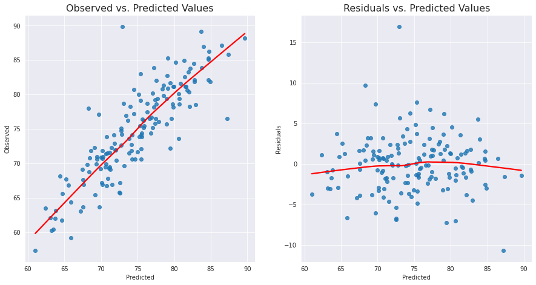

```python
sns.set_style('darkgrid')
sns.mpl.rcParams['figure.figsize'] = (15.0, 7.5)

def linearity_test(model, y):
    '''
    Function for visually inspecting the assumption of linearity in a linear regression model.
    It plots observed vs. predicted values and residuals vs. predicted values.

    Args:
    * model - fitted OLS model from statsmodels
    * y - observed values
    '''
    fitted_vals = model.predict()
    resids = model.resid

    fig, ax = plt.subplots(1,2)

    sns.regplot(x=fitted_vals, y=y, lowess=True, ax=ax[0], line_kws={'color': 'red'})
    ax[0].set_title('Observed vs. Predicted Values', fontsize=16)
    ax[0].set(xlabel='Predicted', ylabel='Observed')

    sns.regplot(x=fitted_vals, y=resids, lowess=True, ax=ax[1], line_kws={'color': 'red'})
    ax[1].set_title('Residuals vs. Predicted Values', fontsize=16)
    ax[1].set(xlabel='Predicted', ylabel='Residuals')

linearity_test(lin_reg, y)
```

We expected that if the data were linear, the first plot would have a diagonal line, the second to have a horizontal, and the variance to be mostly constant. As you can see above, those conditions seem to be satisfied, and therefore we can feel confident that this dataset meets the linearity assumption.

### 3.2. Testing Normality of Residuals

There are several ways to evaluate the normality of the residuals. We can look at QQ plots of the residuals. A QQ plot plots two sets of quantiles against each other if they both come from the same distribution, the points should form a roughly straight line. So let's inspect this QQ plot to see if it looks like a straight line.

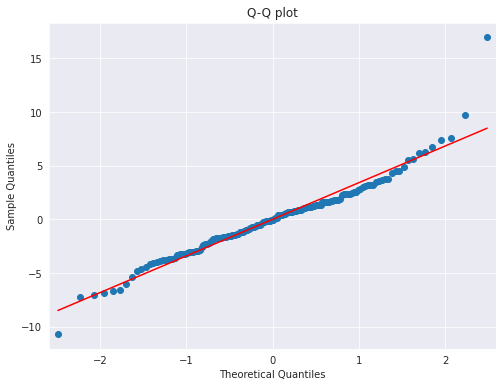

```python
sns.mpl.rcParams['figure.figsize'] = (8.0, 6.0)

sm.ProbPlot(lin_reg.resid).qqplot(line='s');
plt.title('Q-Q plot');
```

This line looks primarily straight with some outliers, which tells us that the residuals have a normal distribution for the most part.

### 3.4. Testing no Autocorrelation of Residuals

Next, we need to see if there is autocorrelation in the residuals. We can test that by performing the Durbin-Watson to detect if there is a positive or negative correlation on the residuals. When the test produces values between 1.5 and 2.5, there is no autocorrelation. When the results are between 0 and 2, there is positive autocorrelation, and when the result is from 2 to 4, there is a negative autocorrelation.

```python
print('Durbin-Watson:', durbin_watson(lin_reg.resid))
```

```
Durbin-Watson: 1.6074095393370116
```

Since the value is between 1.5 and 2.5, we can conclude that there is little to no autocorrelation, and the assumption of no autocorrelation is satisfied.

### 3.5 Testing for Homoscedasticity of Residuals

Now, let's evaluate homoscedasticity. There are several ways to do so. First, we can look at the residuals vs. predicted values from the linearity test and see if the variance seems to be uniform. For the most part, it did. But we will also run a test called the Breusch-Pagan test. In this test, the null hypothesis assumes homoscedasticity, and a p-value below 0.05 will indicate that we need to reject the null hypothesis of homoscedasticity.

```python
def homoscedasticity_test(model):
    '''
    Function for testing the homoscedasticity of residuals in a linear regression model.
    It runs Breusch-Pagan and Goldfeld-Quandt tests.

    Args:
    * model - fitted OLS model from statsmodels
    '''
    fitted_vals = model.predict()
    resids = model.resid
    resids_standardized = model.get_influence().resid_studentized_internal

    bp_test = pd.DataFrame(sms.het_breuschpagan(resids, model.model.exog),
                           columns=['value'],
                           index=['Lagrange multiplier statistic', 'p-value', 'f-value', 'f p-value'])

    print('\n     ---- Breusch-Pagan test ----')
    print(bp_test)

homoscedasticity_test(lin_reg)
```

```
     ---- Breusch-Pagan test ----
                                  value
Lagrange multiplier statistic  0.920000
p-value                        0.921674
f-value                        0.223910
f p-value                      0.924718
```

## Part 4: Data Analysis

Previously, our model was trained on the entire dataset, so the r2 value was based on values the model had already seen. That means we are evaluating the model's accuracy based on data it is trained on, which is problematic because we want to see how it performs on data it's never seen before. To solve this issue, we will split the data up and train our model on most of the data but preserve a small portion of data to test the model on.

We are attempting to make a data model that can take in the top 4 most productive receivers on a team and predict that receiving corp's overall performance (grade). The model will be provided with the receiver grades as the independent variable, and the receiving unit grade will be the dependent variable.

When initially building the model, I sorted players by grade and only included grades as features. It resulted in a model that was very off. There were also issues when changing the order of the grades put into the model because the model would way WR3 and WR4 more because the coefficients were higher. I wanted a way to normalize that a little more, and though including targets would help. It did! I then realized that choosing the top four players and sorting by grade was a bad idea for the reasons I explained above, so I started sorting by targets. Once I sorted the top four players by targets, I was able to remove targets as a feature the model performed very slightly better. I decided not to include targets as a feature of the model, not because the model performed better that way, but because logically, once the model takes into account that the WR1 has the most targets, WR2 has the second most, and so on. Once the model has a way to weigh each receiver by their place on the depth chart, the exact number of targets is unnecessary. If you can get a model working with fewer features, it's better than adding more noise, so I chose to leave the targets out of the training.

```python
x_train, x_test, y_train, y_test = ms.train_test_split(x, y, random_state=42)
print(x_train.size, x_test.size) # this preserves about 25% of the data for testing and 75% for the training
```

```
464 156
```

```python
model = LinearRegression()
model.fit(x_train, y_train)

y_prediction = model.predict(x_test)

# predicting the accuracy score
score = met.r2_score(y_test, y_prediction)
print('r2 score is: ', score)
print('mean_sqrd_error is: ', met.mean_squared_error(y_test,y_prediction))
print('root_mean_squared error of is: ', np.sqrt(met.mean_squared_error(y_test,y_prediction)))
```

```
r2 score is:  0.6686937803480177
mean_sqrd_error is:  20.080659477650432
root_mean_squared error of is:  4.481144884697485
```

## Part 5: Using the Model!

We now have a model that we can use to build the ultimate receiving corp. Now, since this model isn't exactly something we can look at, let's test out the Packers' moves on receiver this offseason and see if they've upgraded. First, we will print out the grades of the top 4 receivers for GB in 2021, the model's receiver unit grade prediction, and the actual grade.

```python
# GB packers top 4 receivers 2021
print_prediction_against_exp(df[(df.team_name == 'GB') & (df.year == 2021)])

def print_prediction_against_exp(row):
    '''
    Takes in a row of data from the dataset and prints out the models'
    prediction against the actual team receiving grade.
    '''
    x = row[['player1_rec_grade', 'player2_rec_grade', 'player3_rec_grade', 'player4_rec_grade']]

    year = row['year'].values[0]
    pg1 = row['player1_rec_grade'].values[0]
    pg2 = row['player2_rec_grade'].values[0]
    pg3 = row['player3_rec_grade'].values[0]
    pg4 = row['player4_rec_grade'].values[0]

    prediction = model.predict(x)
    print('''Receiver corp grade prediction for:
            player 1 grade {},
            player 2 grade {},
            player 3 grade {},
            player 4 grade {},
            is: {}
            while the actual grade is: {}'''.format(pg1, pg2, pg3, pg4,
                                                    prediction[0], row['team_grades_pass_route'].values[0]))

def print_prediction(grades):
    '''
    Takes in a dictionary of grades to targets, and runs the model
    on those grades in order of most to least targets and prints out the result.
    '''
    grade_lst = []

    n = len(grades)
    for _ in range(n):
        temp = max(grades, key=lambda k: grades[k])
        grade_lst.append(temp)
        del grades[temp]

    prediction = model.predict([grade_lst])

    print('''Receiver corp grade prediction for:
            player 1 grade {},
            player 2 grade {},
            player 3 grade {},
            player 4 grade {},
            is: {}'''.format(grade_lst[0], grade_lst[1], grade_lst[2], grade_lst[3], prediction[0]))
```

```
Receiver corp grade prediction for:
            player 1 grade 92.8,
            player 2 grade 63.9,
            player 3 grade 64.6,
            player 4 grade 71.8,
            is: [79.66092441]
            while the actual grade is: 80.1
```

The predicted grade and actual grade are pretty close, which is great. Now I will remove the grades of the receivers that are no longer on the team (Devante Adams - player 1 and Marquez Valdes-Scantling - player 3) and add in their new players using their grades and target numbers from last year or 2020 if they were injured in the previous year. Their receivers will look as follows (grade, targets):

Robert Tonyan (TE): 71.8: 66 \ Allen Lazard (WR): 63.9, 60 \ Sammy Watkins (WR): 64.6, 45 \ Randall Cobb (WR): 71.8, 39

Let's see what the model predicts the unit grade to be.

```python
print_prediction({63.9: 60, 71.8: 39,
                  64.6: 45, 71.8001: 66}) # doing 71.8001 because dictionaries can't handle duplicate keys
```

```
Receiver corp grade prediction for:
            player 1 grade 71.8001,
            player 2 grade 63.9,
            player 3 grade 64.6,
            player 4 grade 71.8,
            is: [70.22872088]
```

As you can see, the Packers have had a real downgrade in the quality of their receiving corp by losing Devante Adams and not replacing him with another star. But I don't think the Packers are the best example of using this model because they didn't even seem to try to replace Adams with several above-average receivers. Let's pretend that we've just entered free agency and we are the general manager of a team and use this model to help us.

Let's pretend we are the GM of the Chargers. First, let's look at our stats from our receiving corp last year.

```python
print_prediction_against_exp(df[(df.team_name == 'LAC') & (df.year == 2021)])
```

```
Receiver corp grade prediction for:
            player 1 grade 77.5,
            player 2 grade 77.6,
            player 3 grade 63.4,
            player 4 grade 59.6,
            is: [73.71206589]
            while the actual grade is: 76.2
```

The model prediction is a little off, likely because several players fall into the WR4 range in terms of targets, but their grades vary. When replacing player 4, Jalen Guyton, who had 46 targets, with Josh Palmer, who had 45 targets but a higher grade, we get a bit closer to the actual score:

```python
print_prediction({77.5: 150, 77.6: 122,
                  63.4: 79, 63.6: 45}) # doing 71.8001 because dictionaries can't handle duplicate keys
```

```
Receiver corp grade prediction for:
            player 1 grade 77.5,
            player 2 grade 77.6,
            player 3 grade 63.4,
            player 4 grade 63.6,
            is: [74.58847051]
```

For reference, player 1 is Keenan Allen, player 2 is Mike Williams, player 3 is Jared Cook (a tight end), and player 4 in the first is Jalen Guyton and Josh Palmer in the second. If we take ourselves back to the start of free agency, as a GM, I am losing Mike Williams and Jared Cook and need to find replacements or resign them. I will consult [PFF's free agency ranker](https://www.pff.com/nfl/free-agency?season=2022) and filter it to wide receivers and tight ends to start evaluating who I should add to my team.

Devante Adams is ranked #1, Chris Godwin is ranked #3, Mike Williams is ranked #7, and Allen Robinson is ranked #10 on the free agency list, which includes all positions, not just receivers. If I wanted to continue with the strategy of being more top-heavy, I'd like to sign one of these receivers and a cheaper tight end. Since Keenan Allen's current contract pays him an average of \$20,025,000, and he is my WR1, I'm looking for another elite receiver I can pay just under that in the top-heavy approach. That would eliminate Adams and Godwin as a potential option, but I still can consider two other receivers. These are the PFF contract projections:

Williams: 4 yrs — \$18m avg/yr Robinson: 3 yrs — \\$16m avg/yr

I also need to think about who my cheaper tight end would be. Zach Ertz is a great but older player who is #64 on PFF's free-agent board, and they project his contract to be 2 yrs — \$10m avg/yr.

Now, since player grades vary each year based on the player's performance, I don't want to only use last year in my evaluation. I should plug in the average of these players' grades from the past three years and plug it into my model to see which receiver, my existing receivers, and Zach Ertz gives me the best grade.

```python
mwGradeMean = receiver_summary[(receiver_summary.player == 'Mike Williams') & (receiver_summary.year >= 2019)]['grades_pass_route'].mean()
mwTargetMean = receiver_summary[(receiver_summary.player == 'Mike Williams') & (receiver_summary.year >= 2019)]['targets'].mean()
arMean = receiver_summary[(receiver_summary.player == 'Allen Robinson II') & (receiver_summary.year >= 2019)]['grades_pass_route'].mean()
arTargetMean = receiver_summary[(receiver_summary.player == 'Allen Robinson II') & (receiver_summary.year >= 2019)]['targets'].mean()
zeMean = receiver_summary[(receiver_summary.player == 'Zach Ertz') & (receiver_summary.year >= 2019)]['grades_pass_route'].mean()
zeTargetMean = receiver_summary[(receiver_summary.player == 'Zach Ertz') & (receiver_summary.year >= 2019)]['targets'].mean()

# arMean
print('Mike Williams grade:', mwMean, ', targets:', mwTargetMean)
print('Allen Robinson II grade:', arMean, ', targets:', arTargetMean)
print('Zach Ertz grade:', zeMean, ', targets:', zeTargetMean)
```

```
Mike Williams grade: 74.83333333333333 , targets: 96.0
Allen Robinson II grade: 78.86666666666666 , targets: 125.33333333333333
Zach Ertz grade: 67.56666666666666 , targets: 104.0
```

So we now have our grades for each of the players we are going to plug in, and we have this function call that we need to modify to remove the players that are free agents:

print_prediction({77.5: 150, 63.6: 45})

and now lets add in each Zach Ertz:

print_prediction({77.5: 150, 63.6: 45, 67.6: 104})

And now let's run it twice, once with Mike Willams, once with Allen Robinson II, and I will re-run last year's receiving corps to compare and see if we've improved as a team.

```python
print('With Mike Williams and Zach Ertz')
print_prediction({77.5: 150, 63.6: 45, zeMean:zeTargetMean, mwMean: mwTargetMean})

print('With Allen Robinson II and Zach Ertz')
print_prediction({77.5: 150, 63.6: 45, zeMean:zeTargetMean, arMean: arTargetMean})

print('2021 Receiving Corp')
print_prediction_against_exp(df[(df.team_name == 'LAC') & (df.year == 2021)])
```

```
With Mike Williams and Zach Ertz
Receiver corp grade prediction for:
            player 1 grade 77.5,
            player 2 grade 67.56666666666666,
            player 3 grade 74.83333333333333,
            player 4 grade 63.6,
            is: [74.43233967]
With Allen Robinson II and Zach Ertz
Receiver corp grade prediction for:
            player 1 grade 77.5,
            player 2 grade 78.86666666666666,
            player 3 grade 67.56666666666666,
            player 4 grade 63.6,
            is: [75.9251175]
2021 Receiving Corp
Receiver corp grade prediction for:
            player 1 grade 77.5,
            player 2 grade 77.6,
            player 3 grade 63.4,
            player 4 grade 59.6,
            is: [73.71206589]
            while the actual grade is: 76.2
```

So we can see with these maneuvers we have improved our team's prediction based on the model even though we didn't outperform our actual grade from 2021. But the goal was to improve on what the model can predict because the amount of improvement that would need to happen to surpass 76.2 when the model initially predicted 73.7 is too far.

Now let's try the strategy of taking two above-average receivers. Wide receiver Odell Beckham Jr and tight end Mike Gesicki are #20 and #22 on the PFF free-agent board and are predicted to make 1 yrs — \$5m avg/yr and 4 yrs — \\$13.25m avg/yr, respectively.

Let's get their average grades from the past three years:

```python
objMean = receiver_summary[(receiver_summary.player == 'Odell Beckham Jr.') & (receiver_summary.year >= 2019)]['grades_pass_route'].mean()
objTargetMean = receiver_summary[(receiver_summary.player == 'Odell Beckham Jr.') & (receiver_summary.year >= 2019)]['targets'].mean()
mgMean = receiver_summary[(receiver_summary.player == 'Mike Gesicki') & (receiver_summary.year >= 2019)]['grades_pass_route'].mean()
mgTargetMean = receiver_summary[(receiver_summary.player == 'Mike Gesicki') & (receiver_summary.year >= 2019)]['targets'].mean()

# arMean
print('Odell Beckham Jr grade:', objMean, ', targets:', mwTargetMean)
print('Mike Gesicki grade:',mgMean, ', targets:', mgTargetMean)
# receiver_summary[(receiver_summary.player == 'Odell Beckham Jr.') & (receiver_summary.year >= 2019)]
```

```
Odell Beckham Jr grade: 72.7 , targets: 96.0
Mike Gesicki grade: 70.23333333333333 , targets: 89.33333333333333
```

```python
print('With Odell Beckham Jr and Mike Gesicki')
print_prediction({77.5: 150, 63.6: 45, objMean: objTargetMean, mgMean: mgTargetMean})

print('2021 Receiving Corp')
print_prediction_against_exp(df[(df.team_name == 'LAC') & (df.year == 2021)])
```

```
With Odell Beckham Jr and Mike Gesicki
Receiver corp grade prediction for:
            player 1 grade 77.5,
            player 2 grade 72.7,
            player 3 grade 70.23333333333333,
            player 4 grade 63.6,
            is: [74.80556049]
2021 Receiving Corp
Receiver corp grade prediction for:
            player 1 grade 77.5,
            player 2 grade 77.6,
            player 3 grade 63.4,
            player 4 grade 59.6,
            is: [73.71206589]
            while the actual grade is: 76.2
```

As you can see, this also outperforms the model's prediction for the 2021 year, which was the goal. In addition, it outperforms my receiving corp with Mike Williams and Zach Ertz, but it does not beat Allen Robinson II and Zach Ertz.

## Part 6: Conclusion

As we've seen in part 5 shows that even within different receiver corp building strategies of top-heavy vs. above average, it depends on how elite and above-average each of the players are. There is no one strategy that is correct across the board, and we should use the data we have to improve our decisions. Data is incredibly powerful, and its predictive ability can make smart teams build their team even better. Data science has been used in football for a while now regarding game-time decisions and player grades, but much more can be done with team building. Team building in a salary-capped league can be boiled down to an optimization problem. There are so many creative solutions NFL teams can come up with to improve their approach to team building and give them a competitive edge.